# Effect of Increasing ICT access on Labor Outcomes for Women in Nepal

2026-02-25

FOR nlsspanel2->Variable 1: Household roster and occupation

```r
Z01C<-read_dta("nlss2panel/Z01C.dta") #Activities
Z01A<-read_dta("nlss2panel/Z01A.dta") #Household roster
Z07B<-read_dta("nlss2panel/Z07B.dta") #Education
```

Rename the ‘IDC’ column to merge

```r
names(Z01C)[names(Z01C)=="V01C_IDC"] <- "IDC"
```

Merge household roster(sex,age,marital status, urban/rural) and occupation

```r
merged_df<-merge(Z01A, Z01C,
                       by=c("WWW","HH","IDC"),all.x=TRUE)
dim(Z01C)
```

```
## [1] 12604    21
```

```r
dim(Z01A)
```

```
## [1] 5519   16
```

```r
dim(merged_df)
```

```
## [1] 13523    34
```

To find model values

```r
summary(Z01C)
```

```
##      WWWHH            WWW              HH             ACT
##  Min.   :  301   Min.   :  3.0   Min.   : 1.000   Length:12604
##  1st Qu.: 7007   1st Qu.: 70.0   1st Qu.: 4.000   Class :character
##  Median :12501   Median :125.0   Median : 9.000   Mode  :character
##  Mean   :13549   Mean   :135.4   Mean   : 9.194
##  3rd Qu.:20616   3rd Qu.:206.0   3rd Qu.:14.000
##  Max.   :26918   Max.   :269.0   Max.   :23.000
##
##       IDC           V01C_01N            V01C_01C      V01C_02
##  Min.   : 1.000   Length:12604       Min.   :111   Min.   : 1.000
##  1st Qu.: 2.000   Class :character   1st Qu.:621   1st Qu.: 4.000
##  Median : 2.000   Mode  :character   Median :742   Median : 8.000
##  Mean   : 3.162                      Mean   :794   Mean   : 7.895
##  3rd Qu.: 4.000                      3rd Qu.:997   3rd Qu.:12.000
##  Max.   :23.000                      Max.   :999   Max.   :12.000
##                                                    NA's   :1687
##     V01C_03         V01C_04          V01C_05         V01C_06H
##  Min.   : 1.00   Min.   : 1.000   Min.   :0.000   Min.   : 1.00
##  1st Qu.: 8.00   1st Qu.: 2.000   1st Qu.:0.000   1st Qu.: 2.00
##  Median :15.00   Median : 4.000   Median :3.000   Median : 4.00
##  Mean   :16.04   Mean   : 4.454   Mean   :3.226   Mean   : 4.06
##  3rd Qu.:25.00   3rd Qu.: 6.000   3rd Qu.:7.000   3rd Qu.: 6.00
##  Max.   :30.00   Max.   :16.000   Max.   :7.000   Max.   :16.00
##  NA's   :1687    NA's   :1687     NA's   :1688    NA's   :5814
##     V01C_06T         V01C_07         V01C_08A        V01C_08B
##  Min.   :  1.00   Min.   :1.000   Min.   : 1.00   Min.   :1.000
##  1st Qu.:  8.00   1st Qu.:1.000   1st Qu.:21.00   1st Qu.:1.000
##  Median : 15.00   Median :1.000   Median :40.00   Median :2.000
##  Mean   : 20.91   Mean   :1.028   Mean   :43.75   Mean   :1.663
##  3rd Qu.: 28.00   3rd Qu.:1.000   3rd Qu.:74.00   3rd Qu.:2.000
##  Max.   :112.00   Max.   :2.000   Max.   :88.00   Max.   :2.000
##  NA's   :5814     NA's   :3597    NA's   :12348   NA's   :12405
##     V01C_09A        V01C_09B        V01C_09C       V01C_09D        V01C_09E
##  Min.   :1       Min.   :1       Min.   :1      Min.   :1       Min.   :1
##  1st Qu.:1       1st Qu.:1       1st Qu.:1      1st Qu.:1       1st Qu.:1
##  Median :1       Median :1       Median :1      Median :1       Median :1
##  Mean   :1       Mean   :1       Mean   :1      Mean   :1       Mean   :1
##  3rd Qu.:1       3rd Qu.:1       3rd Qu.:1      3rd Qu.:1       3rd Qu.:1
##  Max.   :1       Max.   :1       Max.   :1      Max.   :1       Max.   :1
##  NA's   :11898   NA's   :12036   NA's   :8358   NA's   :12155   NA's   :9563
```

```r
summary(Z01A)
```

```
##      WWWHH            WWW              HH              IDC
##  Min.   :  301   Min.   :  3.0   Min.   : 1.000   Min.   : 1.000
##  1st Qu.: 7502   1st Qu.: 75.0   1st Qu.: 4.000   1st Qu.: 2.000
##  Median :13002   Median :130.0   Median : 9.000   Median : 3.000
##  Mean   :13681   Mean   :136.7   Mean   : 9.168   Mean   : 4.007
##  3rd Qu.:20611   3rd Qu.:206.0   3rd Qu.:14.000   3rd Qu.: 5.000
##  Max.   :26918   Max.   :269.0   Max.   :23.000   Max.   :23.000
##
##    V01A_01             V01A_01A         V01A_02         V01A_03
##  Length:5519        Min.   :  1.00   Min.   :1.000   Min.   : 1.000
##  Class :character   1st Qu.:  2.00   1st Qu.:1.000   1st Qu.: 2.000
##  Mode  :character   Median :  6.00   Median :2.000   Median : 3.000
##                     Mean   : 11.48   Mean   :1.512   Mean   : 3.269
##                     3rd Qu.: 14.00   3rd Qu.:2.000   3rd Qu.: 4.000
##                     Max.   :102.00   Max.   :2.000   Max.   :14.000
##
##     V01A_04A        V01A_04B        V01A_05         V01A_06        V01A_07
##  Min.   : 1.00   Min.   :1.000   Min.   : 0.00   Min.   :1.00   Min.   :1.000
##  1st Qu.:17.00   1st Qu.:2.000   1st Qu.:10.00   1st Qu.:1.00   1st Qu.:1.000
##  Median :27.00   Median :2.000   Median :20.00   Median :1.00   Median :1.000
##  Mean   :33.36   Mean   :1.879   Mean   :26.16   Mean   :2.63   Mean   :1.061
##  3rd Qu.:50.00   3rd Qu.:2.000   3rd Qu.:40.00   3rd Qu.:5.00   3rd Qu.:1.000
##  Max.   :93.00   Max.   :2.000   Max.   :99.00   Max.   :5.00   Max.   :2.000
##                  NA's   :156                     NA's   :1271   NA's   :3100
##     V01A_08          V01A_09         V01A_10
##  Min.   : 1.000   Min.   : 0.00   Min.   :1.000
##  1st Qu.: 1.000   1st Qu.:12.00   1st Qu.:1.000
##  Median : 2.000   Median :12.00   Median :1.000
##  Mean   : 2.552   Mean   :11.11   Mean   :1.061
##  3rd Qu.: 3.000   3rd Qu.:12.00   3rd Qu.:1.000
##  Max.   :21.000   Max.   :12.00   Max.   :2.000
##  NA's   :3249
```

```r
summary(Z07B)
```

```
##      WWWHH            WWW              HH            IDC            V07B_01
##  Min.   :  301   Min.   :  3.0   Min.   : 1.0   Min.   : 1.000   Min.   :1.00
##  1st Qu.: 7511   1st Qu.: 75.0   1st Qu.: 4.0   1st Qu.: 1.000   1st Qu.:1.00
##  Median :12407   Median :124.0   Median : 9.0   Median : 3.000   Median :1.00
##  Mean   :13641   Mean   :136.3   Mean   : 9.2   Mean   : 3.039   Mean   :1.08
##  3rd Qu.:20711   3rd Qu.:207.0   3rd Qu.:14.0   3rd Qu.: 4.000   3rd Qu.:1.00
##  Max.   :26918   Max.   :269.0   Max.   :23.0   Max.   :21.000   Max.   :4.00
##
##     V07B_02          V07B_03          V07B_04          V07B_05
##  Min.   : 0.000   Min.   : 1.000   Min.   : 1.000   Min.   : 1.000
##  1st Qu.: 5.000   1st Qu.: 5.000   1st Qu.: 7.000   1st Qu.: 4.000
##  Median : 7.000   Median : 5.000   Median :10.000   Median : 4.000
##  Mean   : 7.404   Mean   : 5.009   Mean   : 8.809   Mean   : 5.277
##  3rd Qu.:11.000   3rd Qu.: 5.000   3rd Qu.:10.000   3rd Qu.: 8.000
##  Max.   :16.000   Max.   :99.000   Max.   :15.000   Max.   :10.000
##                                    NA's   :270
```

Collapse to one row per person for regression

```r
key<-paste(merged_df$WWW, merged_df$HH, merged_df$IDC, sep="_")
merged_one<-merged_df[!duplicated(key), ]
dim(Z01A)
```

```
## [1] 5519   16
```

```r
dim(merged_one)
```

```
## [1] 5519   34
```

Merge education

```r
Z07B_keep<-Z07B[,c("WWW","HH","IDC","V07B_02")]
merged_one <- merge(merged_one, Z07B_keep,
                    by=c("WWW","HH","IDC"),
                    all.x=TRUE)
table(merged_one$V07B_02,useNA="ifany")
```

```
##
##    0    1    2    3    4    5    6    7    8    9   10   11   12   13   14   15
##   10   23   58   78  101  154   78   87   83   54  129  149   80   44   14    1
##   16 <NA>
##    2 4374
```

Create a dummy variable for ‘female’

```r
table(merged_one$V01A_02,useNA="ifany")
```

```
##
##    1    2
## 2692 2827
```

```r
#Create a female dummy(female=1)
merged_one$female<-ifelse(merged_one$V01A_02==2,1,0)

#Check it
table(merged_one$female, useNA="ifany")
```

```
##
##    0    1
## 2692 2827
```

Next,let’s compute labor outcomes

```r
#Creating a variable for calculating labor intensity
merged_one$days_month<-merged_one$V01C_03
merged_one$hours_day<-merged_one$V01C_04

merged_one$hours_month<-merged_one$days_month*merged_one$hours_day

#After calculation, let us summarize the findings
summary(merged_one$hours_month)
```

```
##    Min. 1st Qu.  Median    Mean 3rd Qu.    Max.    NA's
##     1.0    48.0    90.0   103.9   150.0   480.0    2241
```

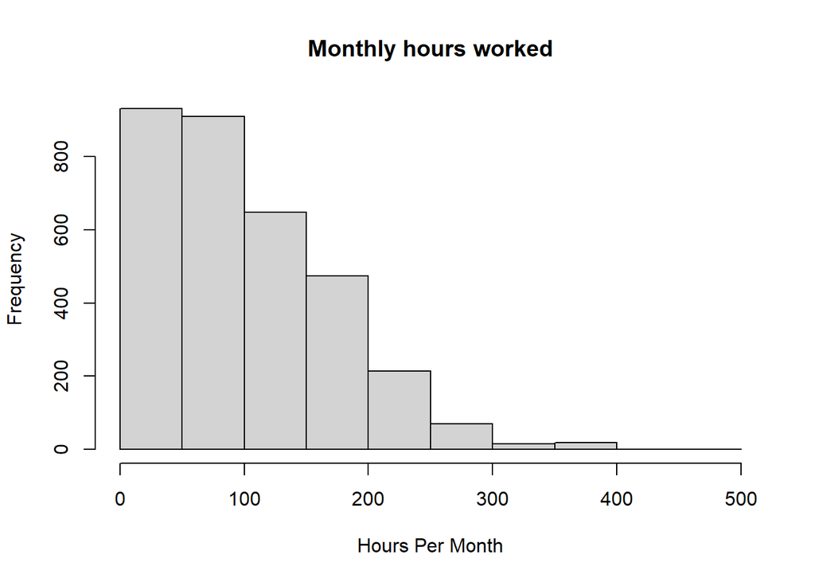

```r
hist(merged_one$hours_month,main="Monthly hours worked",
     xlab="Hours Per Month")
```

Create a dummy of worked variable

```r
merged_one$worked_any<-ifelse(!is.na(merged_one$hours_month)&
merged_one$hours_month>0,1,0)
table(merged_one$worked_any)
```

```
##
##    0    1
## 2241 3278
```

Variable: Internet access

```r
Z02C2<-read_dta("nlss2panel/Z02C2.dta")#Internet access
table(Z02C2$V02C2_11F,useNA="ifany")
```

```
##
##   1   2
##   4 958
```

```r
table(Z02C2$V02C2_11B,useNA="ifany" )
```

```
##
##   1   2
##  10 952
```

Creating ICT (Internet and mobile) dummies and merging

```r
Z02C2$internet<-ifelse(Z02C2$V02C2_11F==1,1,0)
Z02C2$mobile<-ifelse(Z02C2$V02C2_11B==1,1,0)

#Creating combined ICT(Internet or mobile)
Z02C2$ict <- ifelse(Z02C2$internet==1|Z02C2$mobile==1,1,0)

#Avoiding duplicates
Z02C2_keep<-Z02C2[,c("WWW","HH","ict")]

#Merge into merged one
merged_one<-merge(merged_one,Z02C2_keep,
                  by=c("WWW","HH"),
                  all.x=TRUE)
#Households not found
merged_one$ict[is.na(merged_one$ict)]<-0
```

Saving the processed dataset

```r
saveRDS(merged_one, file="processed_merged_one.rds")
write.csv(merged_one,file="processed_merged_one.csv",row.names=FALSE)
```

Performing regression

```r
model<-lm(worked_any~ict*female, data=merged_one)
summary(model)
```

```
##
## Call:
## lm(formula = worked_any ~ ict * female, data = merged_one)
##
## Residuals:
##     Min      1Q  Median      3Q     Max
## -0.6525 -0.5346  0.3475  0.4654  0.5333
##
## Coefficients:
##              Estimate Std. Error t value Pr(>|t|)
## (Intercept)  0.534639   0.009462  56.503   <2e-16 ***
## ict         -0.006861   0.081824  -0.084    0.933
## female       0.117846   0.013212   8.920   <2e-16 ***
## ict:female  -0.178957   0.121272  -1.476    0.140
## ---
## Signif. codes:  0 '***' 0.001 '**' 0.01 '*' 0.05 '.' 0.1 ' ' 1
##
## Residual standard error: 0.4876 on 5515 degrees of freedom
## Multiple R-squared:  0.0147, Adjusted R-squared:  0.01417
## F-statistic: 27.43 on 3 and 5515 DF,  p-value: < 2.2e-16
```

```r
table(merged_one$ict) #For individual level
```

```
##
##    0    1
## 5453   66
```

```r
mean(merged_one$worked_any, na.rm=TRUE)
```

```
## [1] 0.5939482
```

```r
var(merged_one$worked_any, na.rm=TRUE)
```

```
## [1] 0.2412174
```

Mean and variance of ict

```r
mean(merged_one$ict,na.rm=TRUE)
```

```
## [1] 0.01195869
```

```r
var(merged_one$ict,na.rm=TRUE)
```

```
## [1] 0.01181782
```

Mean and variance of hrs/month

```r
mean(merged_one$hours_month,na.rm=TRUE)
```

```
## [1] 103.9201
```

```r
var(merged_one$hours_month,na.rm=TRUE)
```

```
## [1] 5128.483
```

T-test

```r
t.test(worked_any~ict,data=merged_one)
```

```
##
##  Welch Two Sample t-test
##
## data:  worked_any by ict
## t = 1.5245, df = 66.502, p-value = 0.1321
## alternative hypothesis: true difference in means between group 0 and group 1 is not equal to 0
## 95 percent confidence interval:
##  -0.02942823  0.21959878
## sample estimates:
## mean in group 0 mean in group 1
##       0.5950853       0.5000000
```

Correlation and covariance

```r
numeric_vars<-merged_one[,c("worked_any","ict","female","hours_month")]

#Correlation matrix
cor(numeric_vars,use="complete.obs")
```

```
##             worked_any         ict      female hours_month
## worked_any           1          NA          NA          NA
## ict                 NA  1.00000000 -0.02779261   0.1228981
## female              NA -0.02779261  1.00000000  -0.2128359
## hours_month         NA  0.12289814 -0.21283587   1.0000000
```

```r
#Covariance matrix
cov(numeric_vars,use="complete.obs")
```

```
##             worked_any          ict       female hours_month
## worked_any           0  0.000000000  0.000000000    0.000000
## ict                  0  0.009968808 -0.001377303    0.878742
## female               0 -0.001377303  0.246352590   -7.565156
## hours_month          0  0.878742015 -7.565155521 5128.483082
```

Scatterplot

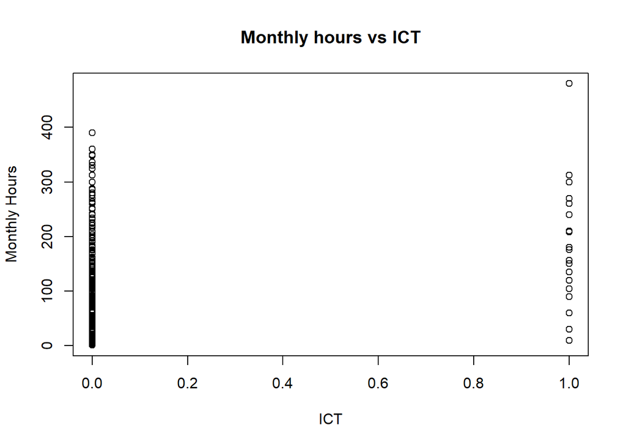

```r
plot(merged_one$ict,
     merged_one$hours_month,
     xlab="ICT",
     ylab="Monthly Hours",
     main="Monthly hours vs ICT")
```

#Adding more controls and Specification

```r
#Age+Age^2
merged_one$age<-merged_one$V01A_05
merged_one$age2<-merged_one$age^2

#Marital status as factor
merged_one$marital<-factor(merged_one$V01A_06)

#Urban / Rural as factor
merged_one$urban<-factor(merged_one$V01A_04B)

merged_one$educ<-factor(merged_one$V07B_02)
```

Run regression with controls

```r
model2<-lm(worked_any~ict*female
             +age+age2
             +marital
             +urban
             +educ,
             data=merged_one)
summary(model2)
```

```
##
## Call:
## lm(formula = worked_any ~ ict * female + age + age2 + marital +
##     urban + educ, data = merged_one)
##
## Residuals:
##      Min       1Q   Median       3Q      Max
## -1.00176 -0.00909  0.01733  0.05925  0.27109
##
## Coefficients:
##               Estimate Std. Error t value Pr(>|t|)
## (Intercept)  8.162e-01  7.234e-02  11.282  < 2e-16 ***
## ict         -5.429e-02  4.225e-02  -1.285 0.199078
## female       4.032e-02  1.165e-02   3.460 0.000561 ***
## age          1.009e-02  2.186e-03   4.619 4.33e-06 ***
## age2        -1.411e-04  2.725e-05  -5.180 2.65e-07 ***
## marital2    -1.653e-02  1.013e-01  -0.163 0.870373
## marital3     4.019e-02  8.700e-02   0.462 0.644167
## marital4    -7.387e-02  4.161e-02  -1.775 0.076143 .
## marital5    -5.552e-02  1.520e-02  -3.653 0.000271 ***
## urban2       5.384e-02  1.425e-02   3.779 0.000166 ***
## educ1       -1.338e-02  6.913e-02  -0.194 0.846527
## educ2       -9.020e-02  6.251e-02  -1.443 0.149314
## educ3       -4.966e-02  6.135e-02  -0.809 0.418456
## educ4       -4.812e-02  6.054e-02  -0.795 0.426926
## educ5       -4.076e-02  5.976e-02  -0.682 0.495375
## educ6       -2.934e-02  6.146e-02  -0.477 0.633204
## educ7       -6.230e-02  6.117e-02  -1.018 0.308687
## educ8       -4.452e-02  6.132e-02  -0.726 0.468007
## educ9       -1.877e-02  6.323e-02  -0.297 0.766692
## educ10      -3.786e-02  6.026e-02  -0.628 0.529979
## educ11      -5.390e-02  6.012e-02  -0.897 0.370177
## educ12      -6.822e-02  6.191e-02  -1.102 0.270782
## educ13       1.697e-03  6.479e-02   0.026 0.979106
## educ14       1.333e-02  7.481e-02   0.178 0.858607
## educ15       2.207e-01  1.863e-01   1.185 0.236416
## educ16      -4.598e-02  1.358e-01  -0.339 0.734947
## ict:female   2.234e-02  7.005e-02   0.319 0.749888
## ---
## Signif. codes:  0 '***' 0.001 '**' 0.01 '*' 0.05 '.' 0.1 ' ' 1
##
## Residual standard error: 0.1729 on 1080 degrees of freedom
##   (4412 observations deleted due to missingness)
## Multiple R-squared:  0.09688,    Adjusted R-squared:  0.07514
## F-statistic: 4.456 on 26 and 1080 DF,  p-value: 1.608e-12
```

Transformation

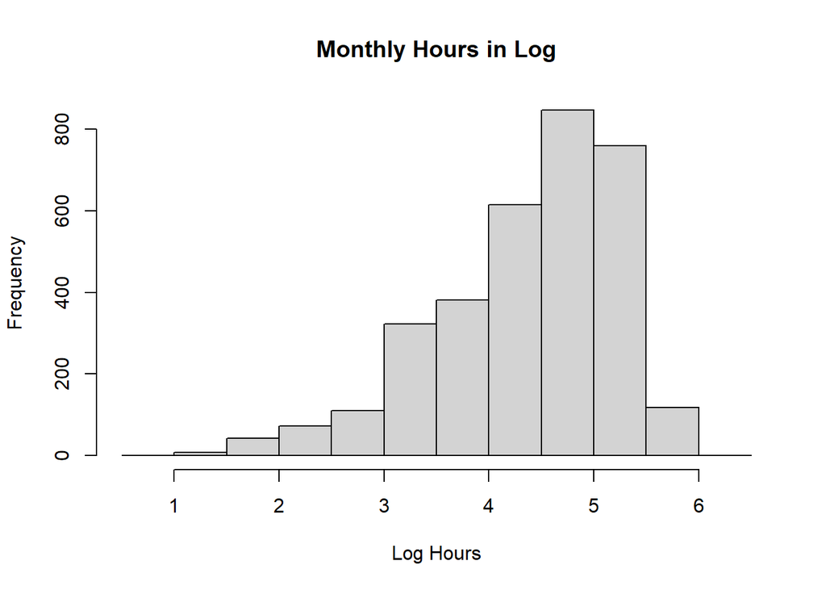

```r
merged_one$log_hours<-log(merged_one$hours_month+1)
hist(merged_one$log_hours,
     main="Monthly Hours in Log",
     xlab="Log Hours")
```

```r
table(merged_one$WWW)
```

```
##
##   3   4   9  11  14  17  18  21  31  32  35  42  45  46  51  53  56  62  66  67
##  30  79  44 102  62  41  60  59  76  69  53  49  48  64  57  49  59  64  91  64
##  68  69  70  75  77  79  81  82  87  89  91  92  94  96  99 101 103 104 106 107
##  51  44  58  73  53  66  69  40  85  66  29  61  37  69  46  57  45  43  74  47
## 112 114 116 117 120 121 124 125 130 136 138 142 147 148 149 150 155 160 163 170
##  67  48  64  32  45  56  63  50  37  55  78 104  95  51  49  75  83  47  47  67
## 172 175 178 179 180 189 190 199 203 205 206 207 208 210 216 219 225 228 232 233
##  64  13  33  69  28  63  55  78  64  63  88  43  53  47  60  36  64  82  44  46
## 234 235 242 247 248 252 254 259 260 261 262 263 264 268 269
##  80  45  71  52  74  69  69  63  33  24  65  94  45  33  63
```

## For the context of nlsspanel2 data, The coefficient on ict is small and statistically insignificant, suggesting that ICT access alone does not significantly affect the probability of working. However, the interaction term between ict and female is negative, suggesting heterogeneous effects by gender, though not statistically significant

## nlss1panel

```r
Z01A_1 <- read_dta("nlss1panel/Z01A.dta")
Z01C_1 <- read_dta("nlss1panel/Z01C.dta")
Z07B_1 <- read_dta("nlss1panel/Z07B.dta")
Z02C2_1 <- read_dta("nlss1panel/Z02C2.dta")

names(Z01C_1)[names(Z01C_1) == "V01C_IDC"] <- "IDC"

# Start from person-level roster
merged_one_1 <- Z01A_1

# Education
Z07B_1_keep <- Z07B_1[, c("WWW","HH","IDC","V07B_02")]
merged_one_1 <- merge(
  merged_one_1, Z07B_1_keep,
  by = c("WWW","HH","IDC"),
  all.x = TRUE
)

# Female
merged_one_1$female <- ifelse(merged_one_1$V01A_02 == 2, 1, 0)

# Labor outcome from total weekly hours in Z01C_1
labor1 <- Z01C_1 %>%
  select(WWW, HH, IDC, V01C_06T) %>%
  mutate(
    hours_worked = ifelse(is.na(V01C_06T), 0, V01C_06T),
    worked_any = ifelse(!is.na(V01C_06T) & V01C_06T > 0, 1, 0)
  ) %>%
  group_by(WWW, HH, IDC) %>%
  summarise(
    hours_worked = sum(hours_worked, na.rm = TRUE),
    worked_any = as.numeric(any(worked_any == 1, na.rm = TRUE)),
    .groups = "drop"
  )

merged_one_1 <- merge(
  merged_one_1, labor1,
  by = c("WWW","HH","IDC"),
  all.x = TRUE
)

merged_one_1$hours_worked[is.na(merged_one_1$hours_worked)] <- 0
merged_one_1$worked_any[is.na(merged_one_1$worked_any)] <- 0

# ICT
Z02C2_1$internet <- ifelse(Z02C2_1$V02C2_11F == 1, 1, 0)
Z02C2_1$mobile   <- ifelse(Z02C2_1$V02C2_11B == 1, 1, 0)
Z02C2_1$ict      <- ifelse(Z02C2_1$internet == 1 | Z02C2_1$mobile == 1, 1, 0)

Z02C2_1_keep <- Z02C2_1[, c("WWW","HH","ict")] %>% distinct()
merged_one_1 <- merge(
  merged_one_1, Z02C2_1_keep,
  by = c("WWW","HH"),
  all.x = TRUE
)
merged_one_1$ict[is.na(merged_one_1$ict)] <- 0

# Controls
merged_one_1$age     <- merged_one_1$V01A_05
merged_one_1$age2    <- merged_one_1$age^2
merged_one_1$marital <- factor(merged_one_1$V01A_06)
merged_one_1$urban   <- factor(merged_one_1$V01A_04B)
merged_one_1$educ    <- factor(merged_one_1$V07B_02)

# Panel identifiers
panel1 <- merged_one_1
panel1$wave <- 1
panel1$pid  <- paste(panel1$WWW, panel1$HH, panel1$IDC, sep = "_")
```

```r
# Panel 2 from NLSS2 baseline dataset
panel2 <- merged_one
panel2$wave <- 2
panel2$pid  <- paste(panel2$WWW, panel2$HH, panel2$IDC, sep = "_")
```

| nlss3panel |
| --- |

```r
summary_stats <- data.frame(
  variable = c("worked_any","ict","female","hours_month","age"),
  mean = c(
    mean(merged_one$worked_any, na.rm=TRUE),
    mean(merged_one$ict, na.rm=TRUE),
    mean(merged_one$female, na.rm=TRUE),
    mean(merged_one$hours_month, na.rm=TRUE),
    mean(merged_one$age, na.rm=TRUE)
  ),
  sd = c(
    sd(merged_one$worked_any, na.rm=TRUE),
    sd(merged_one$ict, na.rm=TRUE),
    sd(merged_one$female, na.rm=TRUE),
    sd(merged_one$hours_month, na.rm=TRUE),
    sd(merged_one$age, na.rm=TRUE)
  )
)

summary_stats
```

```
##      variable         mean         sd
## 1  worked_any   0.59394818  0.4911389
## 2         ict   0.01195869  0.1087098
## 3      female   0.51223048  0.4998957
## 4 hours_month 103.92007322 71.6134281
## 5         age  26.15872441 19.9510953
```

```r
max(merged_one$age, na.rm = TRUE)
```

```
## [1] 99
```

Correction for DiD

```r
# =========================
# NLSS3: use Section 11
# =========================

# Roster
Z01A_3 <- read_dta("nlss3panel/xH01_S01.dta")

# ICT
Z02C2_3 <- read_dta("nlss3panel/xH02_S02.dta")

# Education
Z07B_3 <- read_dta("nlss3panel/xH07_S06B.dta")

# Labor / hours worked (PERSON-LEVEL)
Z11_3 <- read_dta("nlss3panel/xH18_S11.dta")

# -------------------------
# Rename IDs to match
# -------------------------
names(Z01A_3)[names(Z01A_3) == "v01_idc"] <- "IDC"
names(Z07B_3)[names(Z07B_3) == "v06b_idc"] <- "IDC"
names(Z11_3)[names(Z11_3) == "v11_idc"] <- "IDC"

# -------------------------
# Build labor outcomes from S11
# -------------------------
labor3 <- Z11_3 %>%
  select(www, hh, IDC, v11_01) %>%
  mutate(
    hours_worked = ifelse(is.na(v11_01), 0, v11_01),
    worked_any = ifelse(!is.na(v11_01) & v11_01 > 0, 1, 0)
  )

# -------------------------
# Build ICT from Section 2
# -------------------------
Z02C2_3$internet <- ifelse(Z02C2_3$v02_31d == 1, 1, 0)
Z02C2_3$mobile   <- ifelse(Z02C2_3$v02_31b == 1, 1, 0)
Z02C2_3$ict      <- ifelse(Z02C2_3$internet == 1 | Z02C2_3$mobile == 1, 1, 0)

ict3 <- Z02C2_3 %>%
  select(www, hh, ict) %>%
  distinct()

# -------------------------
# Education
# -------------------------
educ3 <- Z07B_3 %>%
  select(www, hh, IDC, v06_04)

# -------------------------
# Merge panel 3 person-level data
# -------------------------
panel3 <- Z01A_3 %>%
  left_join(labor3, by = c("www", "hh", "IDC")) %>%
  left_join(educ3,  by = c("www", "hh", "IDC")) %>%
  left_join(ict3,   by = c("www", "hh"))

# Replace missing values
panel3$ict[is.na(panel3$ict)] <- 0
panel3$worked_any[is.na(panel3$worked_any)] <- 0
panel3$hours_worked[is.na(panel3$hours_worked)] <- 0

# Controls
panel3$female  <- ifelse(panel3$v01_02 == 2, 1, 0)
panel3$urban   <- factor(panel3$v01_04)
panel3$educ    <- factor(panel3$v06_04)
panel3$age     <- panel3$v01_05a
panel3$age2    <- panel3$age^2
panel3$marital <- factor(panel3$v01_06)

# Standardize names for combining
panel3$wave <- 3
panel3$pid  <- paste(panel3$www, panel3$hh, panel3$IDC, sep = "_")
names(panel3)[names(panel3) == "www"] <- "WWW"
names(panel3)[names(panel3) == "hh"]  <- "HH"

# Quick checks
table(panel3$worked_any, useNA = "ifany")
```

```
##
##    0    1
## 1802 3124
```

```r
summary(panel3$hours_worked)
```

```
##    Min. 1st Qu.  Median    Mean 3rd Qu.    Max.
##    0.00    0.00   13.00   23.18   44.00  114.00
```

```r
# =========================
# Rebuild panel_all
# =========================

# Make sure panel1 and panel2 already exist
# and that they have these variables:
# WWW, HH, IDC, pid, wave, worked_any, ict, female, age, age2, marital, urban, educ

common_vars <- c(
  "WWW","HH","IDC","pid","wave",
  "worked_any","ict","female","age","age2","marital","urban","educ"
)

panel1_small <- panel1[, common_vars]
panel2_small <- panel2[, common_vars]
panel3_small <- panel3[, common_vars]

panel_all <- rbind(panel1_small, panel2_small, panel3_small)

# Check worked_any by wave
panel_all %>%
  group_by(wave) %>%
  summarise(
    n = n(),
    mean_worked = mean(worked_any, na.rm = TRUE),
    ict_rate = mean(ict, na.rm = TRUE)
  )
```

```
## # A tibble: 3 × 4
##    wave     n mean_worked ict_rate
##   <dbl> <int>       <dbl>    <dbl>
## 1     1  5771       0.427  0.00173
## 2     2  5519       0.594  0.0120
## 3     3  4926       0.634  0.629
```

```r
# =========================
# DiD setup
# =========================

panel_all$post <- ifelse(panel_all$wave >= 2, 1, 0)
panel_all$did  <- panel_all$ict * panel_all$post

model_df <- panel_all[, c("pid","wave","worked_any","did","age","age2","marital","urban","educ")]
model_df <- na.omit(model_df)

summary(model_df$worked_any)
```

```
##    Min. 1st Qu.  Median    Mean 3rd Qu.    Max.
##  0.0000  1.0000  1.0000  0.8828  1.0000  1.0000
```

```r
table(is.finite(model_df$worked_any), useNA = "ifany")
```

```
##
## TRUE
## 1757
```

```r
# Pooled OLS DiD
m1 <- lm(
  worked_any ~ did + age + age2 + marital + urban + educ,
  data = model_df
)
summary(m1)
```

```
##
## Call:
## lm(formula = worked_any ~ did + age + age2 + marital + urban +
##     educ, data = model_df)
##
## Residuals:
##      Min       1Q   Median       3Q      Max
## -1.05895 -0.03280  0.06385  0.16767  0.63710
##
## Coefficients:
##               Estimate Std. Error t value Pr(>|t|)
## (Intercept)  4.518e-01  1.408e-01   3.210 0.001354 **
## did         -4.554e-03  5.764e-02  -0.079 0.937043
## age          2.660e-02  2.689e-03   9.891  < 2e-16 ***
## age2        -3.271e-04  3.653e-05  -8.956  < 2e-16 ***
## marital1     1.258e-01  1.140e-01   1.104 0.269806
## marital2     2.688e-01  1.134e-01   2.371 0.017850 *
## marital3     1.357e-01  1.175e-01   1.155 0.248187
## marital4     1.999e-01  1.162e-01   1.721 0.085485 .
## marital5     1.534e-01  1.144e-01   1.341 0.180102
## marital6     3.903e-01  1.435e-01   2.720 0.006593 **
## marital7     6.489e-02  1.302e-01   0.498 0.618262
## marital8     3.767e-01  1.410e-01   2.671 0.007635 **
## marital9     1.405e-01  2.042e-01   0.688 0.491608
## urban2       7.415e-02  2.099e-02   3.533 0.000422 ***
## educ1       -1.852e-01  9.681e-02  -1.913 0.055887 .
## educ2       -1.602e-01  8.832e-02  -1.814 0.069789 .
## educ3       -1.379e-01  8.626e-02  -1.599 0.110059
## educ4       -1.108e-01  8.571e-02  -1.293 0.196136
## educ5       -7.955e-02  8.450e-02  -0.941 0.346611
## educ6       -1.026e-01  8.673e-02  -1.183 0.236865
## educ7       -1.215e-01  8.584e-02  -1.416 0.156988
## educ8       -1.333e-01  8.639e-02  -1.544 0.122873
## educ9       -1.472e-01  8.772e-02  -1.678 0.093461 .
## educ10      -1.544e-01  8.458e-02  -1.825 0.068110 .
## educ11      -1.551e-01  8.567e-02  -1.810 0.070394 .
## educ12      -2.431e-01  8.763e-02  -2.774 0.005592 **
## educ13      -2.442e-01  8.989e-02  -2.717 0.006648 **
## educ14      -3.838e-01  1.019e-01  -3.768 0.000170 ***
## educ15      -3.697e-01  1.699e-01  -2.177 0.029636 *
## educ16      -9.691e-02  1.897e-01  -0.511 0.609559
## ---
## Signif. codes:  0 '***' 0.001 '**' 0.01 '*' 0.05 '.' 0.1 ' ' 1
##
## Residual standard error: 0.2954 on 1727 degrees of freedom
## Multiple R-squared:  0.1713, Adjusted R-squared:  0.1574
## F-statistic: 12.31 on 29 and 1727 DF,  p-value: < 2.2e-16
```

```r
# Wave fixed effects
m2 <- feols(
  worked_any ~ did + age + age2 + marital + urban + educ | wave,
  data = model_df,
  cluster = ~pid
)
```

```
## The variables 'urban3', 'urban4', 'urban5', 'urban6', 'urban7', 'urban8' and 5
## others have been removed because of collinearity (see $collin.var).
```

```r
summary(m2)
```

```
## OLS estimation, Dep. Var.: worked_any
## Observations: 1,757
## Fixed-effects: wave: 2
## Standard-errors: Clustered (pid)
##           Estimate Std. Error   t value   Pr(>|t|)
## did      -0.009792   0.051715 -0.189335 8.4986e-01
## age       0.014600   0.003592  4.064526 5.0874e-05 ***
## age2     -0.000196   0.000050 -3.910829 9.6497e-05 ***
## marital1  0.061858   0.187117  0.330582 7.4101e-01
## marital2  0.257923   0.184476  1.398138 1.6230e-01
## marital3  0.121915   0.190632  0.639531 5.2258e-01
## marital4  0.176098   0.188055  0.936420 3.4922e-01
## marital5  0.035089   0.188029  0.186613 8.5199e-01
## marital6  0.380234   0.194832  1.951604 5.1189e-02 .
## marital7  0.053583   0.212519  0.252134 8.0098e-01
## marital8  0.366300   0.201876  1.814486 6.9822e-02 .
## marital9  0.129200   0.302580  0.426996 6.6945e-01
## urban2    0.017065   0.020816  0.819802 4.1247e-01
## educ1    -0.172154   0.065519 -2.627558 8.6963e-03 **
## educ2    -0.154506   0.050897 -3.035625 2.4458e-03 **
## educ3    -0.131776   0.044214 -2.980378 2.9298e-03 **
## educ4    -0.106655   0.042228 -2.525700 1.1659e-02 *
## educ5    -0.079794   0.039372 -2.026662 4.2891e-02 *
## educ6    -0.101169   0.040787 -2.480413 1.3243e-02 *
## educ7    -0.118942   0.044632 -2.664940 7.7909e-03 **
## educ8    -0.131787   0.044732 -2.946164 3.2719e-03 **
## educ9    -0.141970   0.049629 -2.860593 4.2929e-03 **
## educ10   -0.143928   0.041495 -3.468576 5.3949e-04 ***
## educ11   -0.156383   0.041472 -3.770767 1.6969e-04 ***
## educ12   -0.241053   0.052838 -4.562141 5.5177e-06 ***
## educ13   -0.235151   0.054389 -4.323509 1.6471e-05 ***
## educ14   -0.381238   0.085075 -4.481183 8.0433e-06 ***
## educ15   -0.371097   0.147532 -2.515363 1.2005e-02 *
## educ16   -0.068715   0.062563 -1.098342 2.7225e-01
## ... 11 variables were removed because of collinearity (urban3, urban4
## and 9 others [full set in $collin.var])
## ---
## Signif. codes:  0 '***' 0.001 '**' 0.01 '*' 0.05 '.' 0.1 ' ' 1
## RMSE: 0.290644     Adj. R2: 0.169631
##                  Within R2: 0.077119
```

```r
# Individual + wave FE on balanced sample
pid_counts <- table(model_df$pid)
model_df_bal <- model_df[model_df$pid %in% names(pid_counts[pid_counts >= 2]), ]

m3 <- feols(
  worked_any ~ did + age + age2 + marital + urban + educ | pid + wave,
  data = model_df_bal,
  cluster = ~pid
)
```

```
## The variables 'urban3', 'urban4', 'urban5', 'urban6', 'urban7', 'urban8' and 5
## others have been removed because of collinearity (see $collin.var).
```

```r
summary(m3)
```

```
## OLS estimation, Dep. Var.: worked_any
## Observations: 780
## Fixed-effects: pid: 390,  wave: 2
## Standard-errors: Clustered (pid)
##           Estimate Std. Error    t value   Pr(>|t|)
## did       0.231274   0.116482   1.985487 4.7792e-02 *
## age      -0.012378   0.012241  -1.011203 3.1255e-01
## age2      0.000148   0.000134   1.103384 2.7054e-01
## marital1  0.028860   0.207946   0.138788 8.8969e-01
## marital2  0.233269   0.203683   1.145256 2.5281e-01
## marital3  0.199195   0.212176   0.938819 3.4841e-01
## marital4  0.213166   0.208597   1.021903 3.0746e-01
## marital5 -0.227174   0.292263  -0.777294 4.3746e-01
## marital6  0.475115   0.240742   1.973541 4.9141e-02 *
## marital7  0.370517   0.297322   1.246180 2.1345e-01
## marital8  0.218367   0.346192   0.630768 5.2856e-01
## marital9 -1.098303   0.310661  -3.535376 4.5624e-04 ***
## urban2   -0.407700   0.062120  -6.563102 1.6863e-10 ***
## educ1    -0.995382   0.093675 -10.625954  < 2.2e-16 ***
## educ2    -0.802770   0.119969  -6.691458 7.7226e-11 ***
## educ3    -1.009855   0.100213 -10.077066  < 2.2e-16 ***
## educ4    -0.901585   0.095589  -9.431938  < 2.2e-16 ***
## educ5    -0.867340   0.094237  -9.203809  < 2.2e-16 ***
## educ6    -0.923435   0.027458 -33.631357  < 2.2e-16 ***
## educ7    -0.914682   0.082590 -11.074963  < 2.2e-16 ***
## educ8    -1.092668   0.101106 -10.807170  < 2.2e-16 ***
## educ9    -0.933948   0.097653  -9.563987  < 2.2e-16 ***
## educ10   -0.912569   0.093212  -9.790238  < 2.2e-16 ***
## educ11   -0.827774   0.105362  -7.856489 3.9009e-14 ***
## educ12   -0.778184   0.127723  -6.092727 2.6710e-09 ***
## educ13   -0.739906   0.162977  -4.539929 7.5137e-06 ***
## educ14   -0.848591   0.290473  -2.921407 3.6877e-03 **
## educ15   -0.834480   0.102512  -8.140305 5.3922e-15 ***
## educ16   -0.608616   0.310422  -1.960609 5.0638e-02 .
## ... 11 variables were removed because of collinearity (urban3, urban4
## and 9 others [full set in $collin.var])
## ---
## Signif. codes:  0 '***' 0.001 '**' 0.01 '*' 0.05 '.' 0.1 ' ' 1
## RMSE: 0.184314     Adj. R2: 0.388505
##                  Within R2: 0.272778
```

```r
# =========================
# DiD trend graph
# =========================
png("did_trend_graph.png", width = 1200, height = 800)
plot_data <- panel_all %>%
  filter(female == 1) %>%
  group_by(wave, ict) %>%
  summarise(
    emp_rate = mean(worked_any, na.rm = TRUE),
    n = n(),
    .groups = "drop"
  )

plot(emp_rate ~ wave, data = subset(plot_data, ict == 1),
     type = "b", pch = 16, ylim = c(0,1),
     xlab = "Wave", ylab = "Employment Rate",
     main = "Female Employment trends by ICT status")

lines(emp_rate ~ wave, data = subset(plot_data, ict == 0),
      type = "b", pch = 17)

legend("topright", legend = c("ICT = 1", "ICT = 0"), pch = c(16,17), lty = 1)
abline(v = 1.5, lty = 2)
dev.off()
```

```r
panel_all %>%
  group_by(wave) %>%
  summarise(
    n = n(),
    mean_worked = mean(worked_any, na.rm = TRUE),
    ict_rate = mean(ict, na.rm = TRUE)
  )
```

```
## # A tibble: 3 × 4
##    wave     n mean_worked ict_rate
##   <dbl> <int>       <dbl>    <dbl>
## 1     1  5771       0.427  0.00173
## 2     2  5519       0.594  0.0120
## 3     3  4926       0.634  0.629
```

```r
panel1 %>%
  summarise(
    n = n(),
    nonmissing_hours = sum(!is.na(hours_worked)),
    mean_worked = mean(worked_any, na.rm = TRUE)
  )
```

```
##      n nonmissing_hours mean_worked
## 1 5771             5771   0.4269624
```

```r
panel2 %>%
  summarise(
    n = n(),
    nonmissing_hours = sum(!is.na(hours_month)),
    mean_worked = mean(worked_any, na.rm = TRUE)
  )
```

```
##      n nonmissing_hours mean_worked
## 1 5519             3278   0.5939482
```

```r
panel3 %>%
  summarise(
    n = n(),
    nonmissing_hours = sum(!is.na(hours_worked)),
    mean_worked = mean(worked_any, na.rm = TRUE)
  )
```

```
## # A tibble: 1 × 3
##       n nonmissing_hours mean_worked
##   <int>            <int>       <dbl>
## 1  4926             4926       0.634
```

```r
summary_stats <- data.frame(
  Variable = c("worked_any", "ict", "female", "hours_month", "age"),
  Mean = c(
    mean(merged_one$worked_any, na.rm = TRUE),
    mean(merged_one$ict, na.rm = TRUE),
    mean(merged_one$female, na.rm = TRUE),
    mean(merged_one$hours_month, na.rm = TRUE),
    mean(merged_one$age, na.rm = TRUE)
  ),
  SD = c(
    sd(merged_one$worked_any, na.rm = TRUE),
    sd(merged_one$ict, na.rm = TRUE),
    sd(merged_one$female, na.rm = TRUE),
    sd(merged_one$hours_month, na.rm = TRUE),
    sd(merged_one$age, na.rm = TRUE)
  ),
  Min = c(
    min(merged_one$worked_any, na.rm = TRUE),
    min(merged_one$ict, na.rm = TRUE),
    min(merged_one$female, na.rm = TRUE),
    min(merged_one$hours_month, na.rm = TRUE),
    min(merged_one$age, na.rm = TRUE)
  ),
  Max = c(
    max(merged_one$worked_any, na.rm = TRUE),
    max(merged_one$ict, na.rm = TRUE),
    max(merged_one$female, na.rm = TRUE),
    max(merged_one$hours_month, na.rm = TRUE),
    max(merged_one$age, na.rm = TRUE)
  ),
  N = c(
    sum(!is.na(merged_one$worked_any)),
    sum(!is.na(merged_one$ict)),
    sum(!is.na(merged_one$female)),
    sum(!is.na(merged_one$hours_month)),
    sum(!is.na(merged_one$age))
  )
)
kable(summary_stats, digits = 3, caption = "Summary Statistics")
```

Summary Statistics

| Variable | Mean | SD | Min | Max | N |
| --- | --- | --- | --- | --- | --- |
| worked_any | 0.594 | 0.491 | 0 | 1 | 5519 |
| ict | 0.012 | 0.109 | 0 | 1 | 5519 |
| female | 0.512 | 0.500 | 0 | 1 | 5519 |
| hours_month | 103.920 | 71.613 | 1 | 480 | 3278 |
| age | 26.159 | 19.951 | 0 | 99 | 5519 |

Summary for Findings

```r
modelsummary(
  list(
    "Wave FE" = m2,
    "Individual + Wave FE" = m3
  ),
  stars=TRUE,
  output="kableExtra"
)
```

|  | Wave FE | &nbsp;Individual + Wave FE |
| --- | --- | --- |
| did | −0.010 | 0.231* |
|  | (0.052) | (0.116) |
| age | 0.015*** | −0.012 |
|  | (0.004) | (0.012) |
| age2 | −0.000*** | 0.000 |
|  | (0.000) | (0.000) |
| marital1 | 0.062 | 0.029 |
|  | (0.187) | (0.208) |
| marital2 | 0.258 | 0.233 |
|  | (0.184) | (0.204) |
| marital3 | 0.122 | 0.199 |
|  | (0.191) | (0.212) |
| marital4 | 0.176 | 0.213 |
|  | (0.188) | (0.209) |
| marital5 | 0.035 | −0.227 |
|  | (0.188) | (0.292) |
| marital6 | 0.380+ | 0.475* |
|  | (0.195) | (0.241) |
| marital7 | 0.054 | 0.371 |
|  | (0.213) | (0.297) |
| marital8 | 0.366+ | 0.218 |
|  | (0.202) | (0.346) |
| marital9 | 0.129 | −1.098*** |
|  | (0.303) | (0.311) |
| urban2 | 0.017 | −0.408*** |
|  | (0.021) | (0.062) |
| educ1 | −0.172** | −0.995*** |
|  | (0.066) | (0.094) |
| educ2 | −0.155** | −0.803*** |
|  | (0.051) | (0.120) |
| educ3 | −0.132** | −1.010*** |
|  | (0.044) | (0.100) |
| educ4 | −0.107* | −0.902*** |
|  | (0.042) | (0.096) |
| educ5 | −0.080* | −0.867*** |
|  | (0.039) | (0.094) |
| educ6 | −0.101* | −0.923*** |
|  | (0.041) | (0.027) |
| educ7 | −0.119** | −0.915*** |
|  | (0.045) | (0.083) |
| educ8 | −0.132** | −1.093*** |
|  | (0.045) | (0.101) |
| educ9 | −0.142** | −0.934*** |
|  | (0.050) | (0.098) |
| educ10 | −0.144*** | −0.913*** |
|  | (0.041) | (0.093) |
| educ11 | −0.156*** | −0.828*** |
|  | (0.041) | (0.105) |
| educ12 | −0.241*** | −0.778*** |
|  | (0.053) | (0.128) |
| educ13 | −0.235*** | −0.740*** |
|  | (0.054) | (0.163) |
| educ14 | −0.381*** | −0.849** |
|  | (0.085) | (0.290) |
| educ15 | −0.371* | −0.834*** |
|  | (0.148) | (0.103) |
| educ16 | −0.069 | −0.609+ |
|  | (0.063) | (0.310) |
| Num.Obs. | 1757 | 780 |
| R2 | 0.184 | 0.717 |
| R2 Adj. | 0.170 | 0.389 |
| R2 Within | 0.077 | 0.273 |
| R2 Within Adj. | 0.062 | 0.214 |
| AIC | 706.1 | 415.4 |
| BIC | 875.7 | 2372.3 |
| RMSE | 0.29 | 0.18 |
| Std.Errors | by: pid | by: pid |
| FE: wave | X | X |
| FE: pid |  | X |

+ p < 0.1, * p < 0.05, ** p < 0.01, *** p < 0.001

Table to cleanly display output

```r
modelsummary(
  list(
    "Wave FE" = m2,
    "Individual + Wave FE" = m3
  ),
  stars = TRUE,
  escape = FALSE,
  coef_map = c(
    "did" = "ICT Access×Post",
    "age" = "Age",
    "age2" = "Age²"
  ),
  output = "kableExtra"
)
```

|  | Wave FE | Individual + Wave FE |
| --- | --- | --- |
| ICT Access×Post | −0.010 | 0.231* |
|  | (0.052) | (0.116) |
| Age | 0.015*** | −0.012 |
|  | (0.004) | (0.012) |
| Age² | −0.000*** | 0.000 |
|  | (0.000) | (0.000) |
| Num.Obs. | 1757 | 780 |
| R2 | 0.184 | 0.717 |
| R2 Adj. | 0.170 | 0.389 |
| R2 Within | 0.077 | 0.273 |
| R2 Within Adj. | 0.062 | 0.214 |
| AIC | 706.1 | 415.4 |
| BIC | 875.7 | 2372.3 |
| RMSE | 0.29 | 0.18 |
| Std.Errors | by: pid | by: pid |
| FE: wave | X | X |
| FE: pid |  | X |

+ p < 0.1, * p < 0.05, ** p < 0.01, *** p < 0.001